# SU_25_River_Rockfish_Proj_Ambient_V0.2

Parametric assumptions: - Normality (Shapiro-Wilk test): **Met** - Variance (Bartletts test): NA

- Nonparametric variance (Levene’s test): **Met**

Differences: Between Fecundity Class

```r
# hct
# Ambient ANOVA Test

# Testing for differences in ambient parturition success metrics
# One-way ANOVA (parametric) or Kruskal-Wallis test (nonparametric)

hct_aov_ambient_fec <- aov(Hct.... ~ Fecundity_Class, data = Ambient_Samples)
summary(hct_aov_ambient_fec)
```

```
##                 Df Sum Sq Mean Sq F value Pr(>F)
## Fecundity_Class  2  73.83   36.92   4.824  0.021 *
## Residuals       18 137.74    7.65
## ---
## Signif. codes:  0 '***' 0.001 '**' 0.01 '*' 0.05 '.' 0.1 ' ' 1
```

```r
# If significant, Post Hoc Test:
# - Tukey's HSD (parametric, normality & equal variance across groups)
# - Dunn's test (non-parametric, after Kruskal-Wallis test)

TukeyHSD(hct_aov_ambient_fec)
```

```
##   Tukey multiple comparisons of means
##     95% family-wise confidence level
##
## Fit: aov(formula = Hct.... ~ Fecundity_Class, data = Ambient_Samples)
##
## $Fecundity_Class
##                              diff        lwr      upr     p adj
## Low (~1,000s)-High (>50,000) -3.4 -8.3921454 1.592145 0.2186627
## Atresia-High (>50,000)        1.5 -2.5366864 5.536686 0.6176987
## Atresia-Low (~1,000s)         4.9  0.8633136 8.936686 0.0162654
```

```r
# Parametric tests

# Normality
shapiro.test(Ambient_Samples$Hct....)
```

```
##
##  Shapiro-Wilk normality test
##
## data:  Ambient_Samples$Hct....
## W = 0.97482, p-value = 0.8355
```

```r
shapiro.test(residuals(aov(Hct.... ~ Fecundity_Class, data = Ambient_Samples)))
```

```
##
##  Shapiro-Wilk normality test
##
## data:  residuals(aov(Hct.... ~ Fecundity_Class, data = Ambient_Samples))
## W = 0.97094, p-value = 0.7538
```

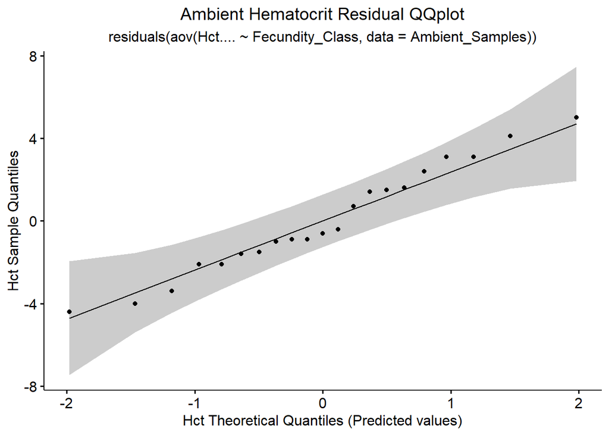

```r
# QQplot:
hct_ambient_fec_res_qqplot <- ggqqplot(residuals(aov(Hct.... ~ Fecundity_Class, data = Ambient_Samples))) +
labs(title = "Ambient Hematocrit Residual QQplot",
     subtitle = "residuals(aov(Hct.... ~ Fecundity_Class, data = Ambient_Samples))",
                               x = "Hct Theoretical Quantiles (Predicted values)",
                               y = "Hct Sample Quantiles") +
  theme(plot.title = element_text(hjust = 0.5),
        plot.subtitle = element_text(hjust = 0.5))
print(hct_ambient_fec_res_qqplot)
```

```r
# Parametric Variance test (Bartlett's test): require at least 2 obs for each group
bartlett.test(Hct.... ~ Fecundity_Class, data = Ambient_Samples)
```

```
##
##  Bartlett test of homogeneity of variances
##
## data:  Hct.... by Fecundity_Class
## Bartlett's K-squared = 1.7219, df = 2, p-value = 0.4228
```

```r
# Nonparametric variance test (Levene's test):
leveneTest(Hct.... ~ Fecundity_Class, data = Ambient_Samples)
```

```
## Levene's Test for Homogeneity of Variance (center = median)
##       Df F value Pr(>F)
## group  2  1.2003 0.3241
##       18
```

```r
# Nonparametric stat test: Kruskall Wallis
kruskal.test(Hct.... ~ Fecundity_Class, data = Ambient_Samples)
```

```
##
##  Kruskal-Wallis rank sum test
##
## data:  Hct.... by Fecundity_Class
## Kruskal-Wallis chi-squared = 6.7821, df = 2, p-value = 0.03367
```

```r
# Nonparametric Post Hoc: Dunn's Test
DunnettTest(Hct.... ~ Fecundity_Class, data = Ambient_Samples)
```

```
##
##   Dunnett's test for comparing several treatments with a control :
##     95% family-wise confidence level
##
## $`High (>50,000)`
##                              diff    lwr.ci   upr.ci   pval
## Low (~1,000s)-High (>50,000) -3.4 -8.050930 1.250930 0.1642
## Atresia-High (>50,000)        1.5 -2.260777 5.260777 0.5289
##
## ---
## Signif. codes:  0 '***' 0.001 '**' 0.01 '*' 0.05 '.' 0.1 ' ' 1
```

Hct Ambient Results

Which fecundity class significantly different (if any)? - Atresia-Low (~1,000s): (Tukey HSD: p adj = 0.0162654)

Parametric assumptions: - Normality (Shapiro-Wilk test): **Met** - Variance (Bartlett’s test): **Met**

Nonparametric variance test (Levene’s test): **Met**

Correlations: Parameter to Numerical Fecundity (without Atresia IDs)

```r
# hct
# Linear Model
hct_amb_fec_no_atresia_lm <- lm(Hct.... ~ Weight_Adjusted_Fecundity_Fecundity.Mean_Weight, data = Fecundity_No_Atresia_Samples)
summary(hct_amb_fec_no_atresia_lm)
```

```
##
## Call:
## lm(formula = Hct.... ~ Weight_Adjusted_Fecundity_Fecundity.Mean_Weight,
##     data = Fecundity_No_Atresia_Samples)
##
## Residuals:
##     Min      1Q  Median      3Q     Max
## -3.4692 -1.9674 -0.8183  1.4654  7.1131
##
## Coefficients:
##                                                 Estimate Std. Error t value
## (Intercept)                                     13.09179    2.12136   6.171
## Weight_Adjusted_Fecundity_Fecundity.Mean_Weight  0.01313    0.01112   1.181
##                                                 Pr(>|t|)
## (Intercept)                                     0.000268 ***
## Weight_Adjusted_Fecundity_Fecundity.Mean_Weight 0.271681
## ---
## Signif. codes:  0 '***' 0.001 '**' 0.01 '*' 0.05 '.' 0.1 ' ' 1
##
## Residual standard error: 3.357 on 8 degrees of freedom
##   (18 observations deleted due to missingness)
## Multiple R-squared:  0.1484, Adjusted R-squared:  0.04192
## F-statistic: 1.394 on 1 and 8 DF,  p-value: 0.2717
```

```
## qu = 0.5, log(sigma) = -3.130892 : outer Newton did not converge fully.
```

```
## qu = 0.5, log(sigma) = -3.137393 : outer Newton did not converge fully.
```

```
## qu = 0.5, log(sigma) = -3.148809 : outer Newton did not converge fully.
```

```
## qu = 0.5, log(sigma) = -3.14559 : outer Newton did not converge fully.
```

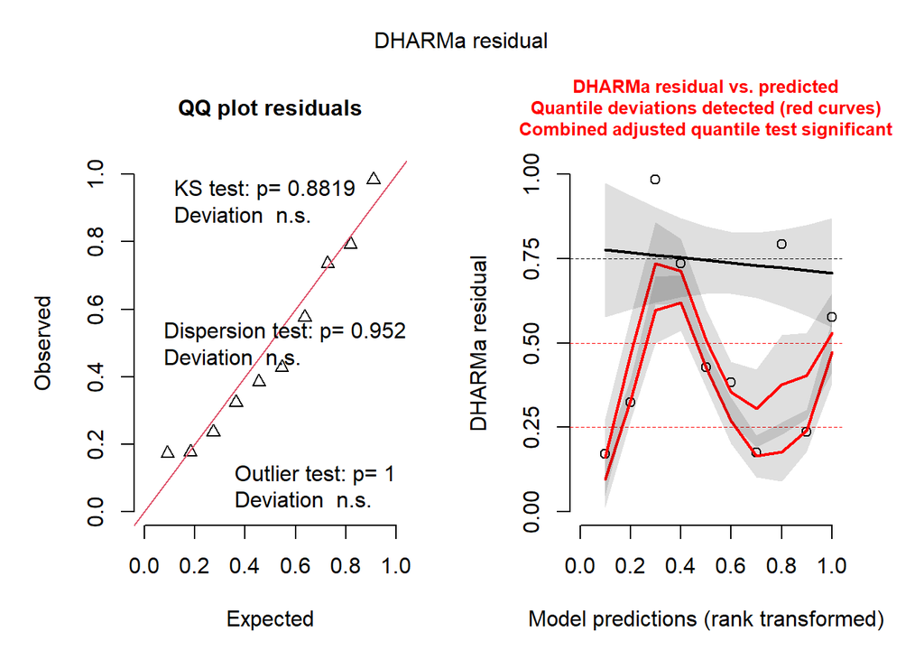

```r
hct_ambient_sim <- simulateResiduals(fittedModel = hct_amb_fec_no_atresia_lm)
plot(hct_ambient_sim)
```

```
## qu = 0.5, log(sigma) = -3.130892 : outer Newton did not converge fully.
```

```
## qu = 0.5, log(sigma) = -3.137393 : outer Newton did not converge fully.
```

```
## qu = 0.5, log(sigma) = -3.148809 : outer Newton did not converge fully.
```

```
## qu = 0.5, log(sigma) = -3.14559 : outer Newton did not converge fully.
```

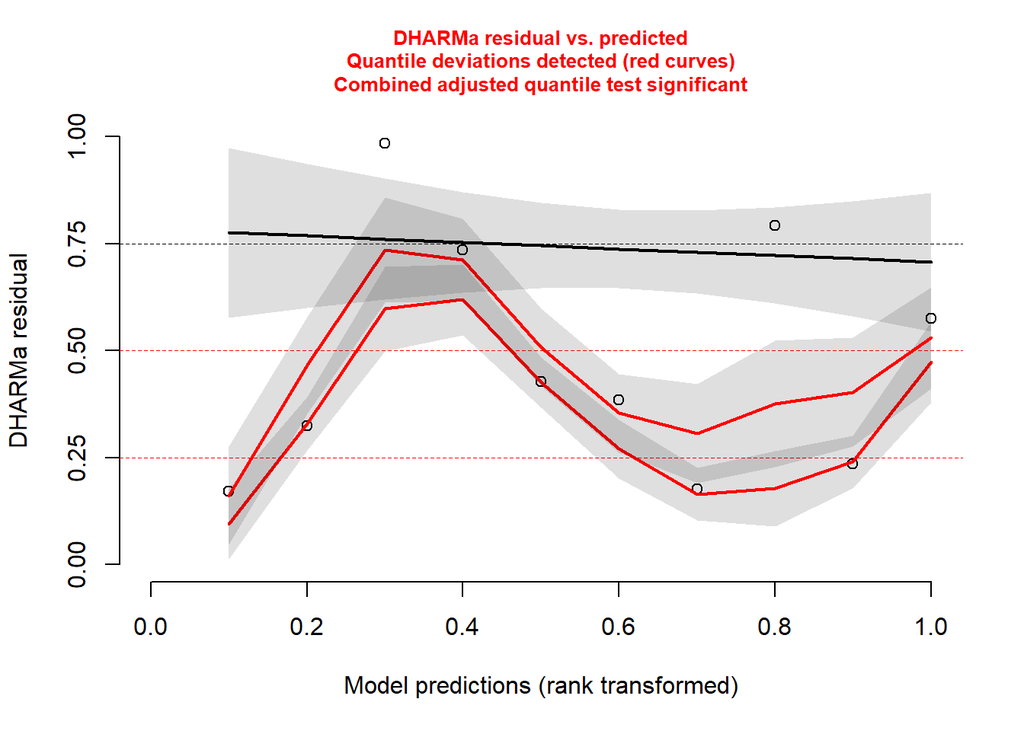

```r
plotResiduals(hct_amb_fec_no_atresia_lm)
```

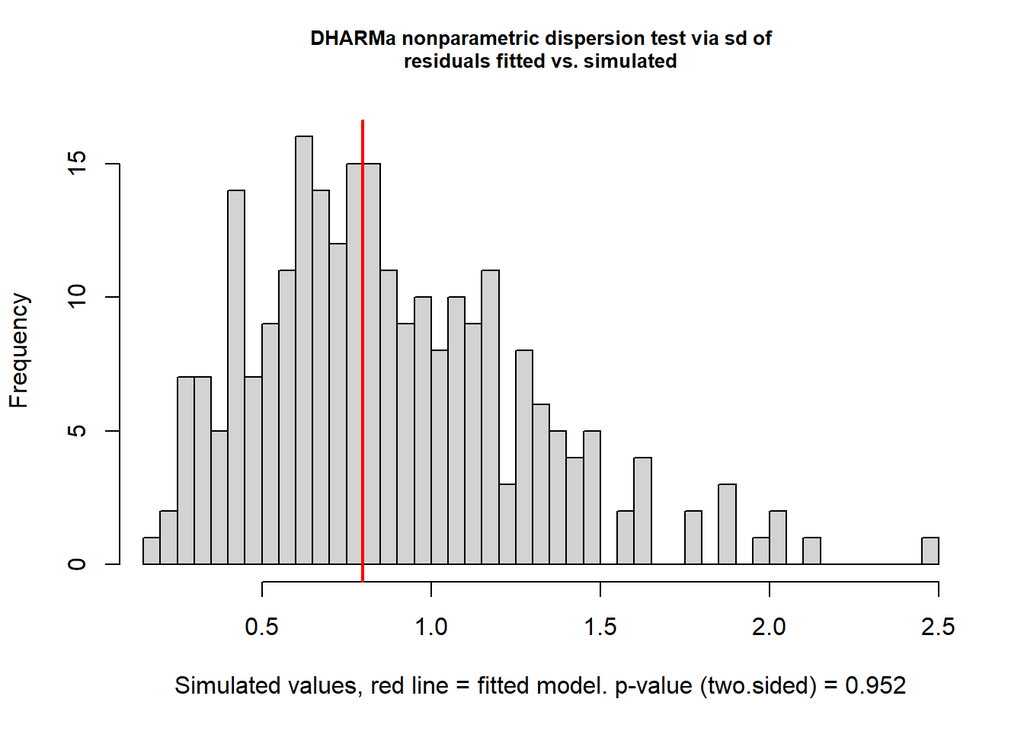

```
##
##  DHARMa nonparametric dispersion test via sd of residuals fitted vs.
##  simulated
##
## data:  simulationOutput
## dispersion = 0.90609, p-value = 0.952
## alternative hypothesis: two.sided
```

```r
testDispersion(hct_amb_fec_no_atresia_lm)
```

```r
# Normality test
shapiro.test(residuals(hct_amb_fec_no_atresia_lm))
```

```
##
##  Shapiro-Wilk normality test
##
## data:  residuals(hct_amb_fec_no_atresia_lm)
## W = 0.89945, p-value = 0.2161
```

```r
# Transform data: square root (undo log scale?)
hct_ambient_sqrt <- Amb_Fec_No_Atresia_Samples %>%
  mutate(Hct.... = sqrt(Hct....))

# Rerun lm model with square root transformed data
hct_amb_fec_no_atresia_lm_sqrt <- lm(Hct.... ~ Weight_Adjusted_Fecundity_Fecundity.Mean_Weight, data = hct_ambient_sqrt)
summary(hct_amb_fec_no_atresia_lm_sqrt)
```

```
##
## Call:
## lm(formula = Hct.... ~ Weight_Adjusted_Fecundity_Fecundity.Mean_Weight,
##     data = hct_ambient_sqrt)
##
## Residuals:
##      Min       1Q   Median       3Q      Max
## -0.45751 -0.18537 -0.07738  0.06130  0.87682
##
## Coefficients:
##                                                 Estimate Std. Error t value
## (Intercept)                                     3.549914   0.292111  12.153
## Weight_Adjusted_Fecundity_Fecundity.Mean_Weight 0.002034   0.001664   1.223
##                                                 Pr(>|t|)
## (Intercept)                                     1.89e-05 ***
## Weight_Adjusted_Fecundity_Fecundity.Mean_Weight    0.267
## ---
## Signif. codes:  0 '***' 0.001 '**' 0.01 '*' 0.05 '.' 0.1 ' ' 1
##
## Residual standard error: 0.456 on 6 degrees of freedom
## Multiple R-squared:  0.1995, Adjusted R-squared:  0.06603
## F-statistic: 1.495 on 1 and 6 DF,  p-value: 0.2673
```

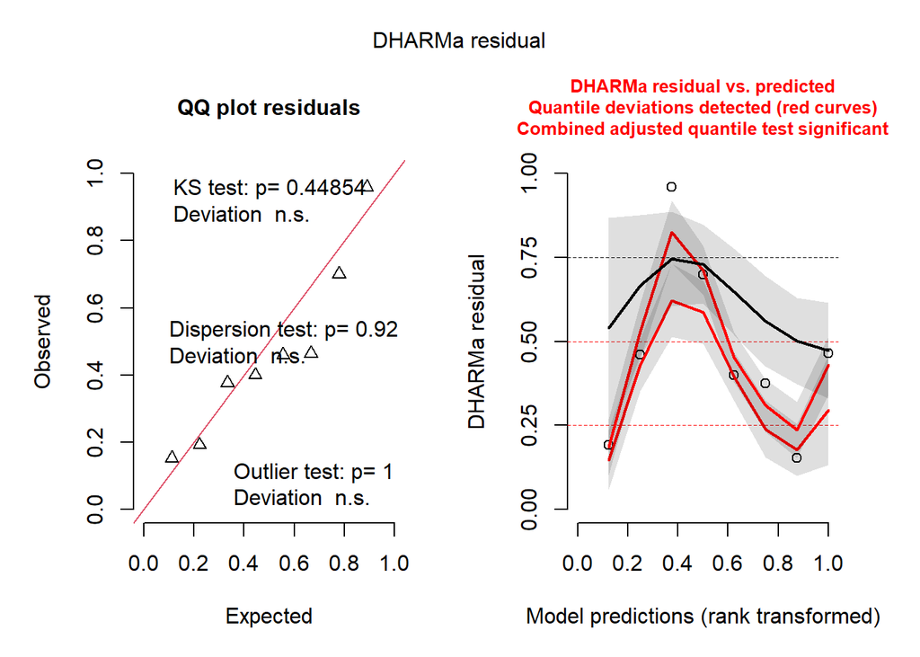

```r
hct_amb_fec_sqrt_sim <- simulateResiduals(fittedModel = hct_amb_fec_no_atresia_lm_sqrt)
plot(hct_amb_fec_sqrt_sim)
```

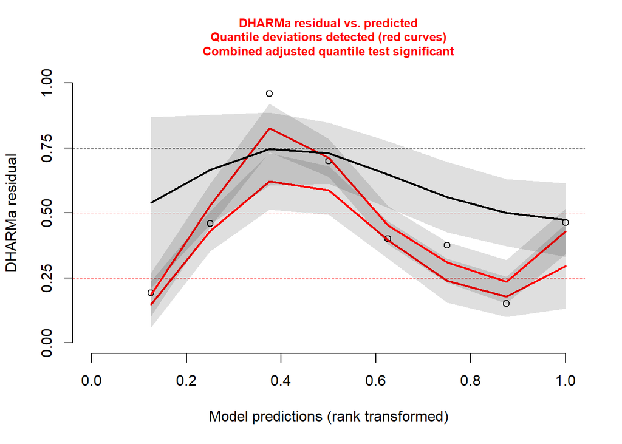

```r
plotResiduals(hct_amb_fec_no_atresia_lm_sqrt)
```

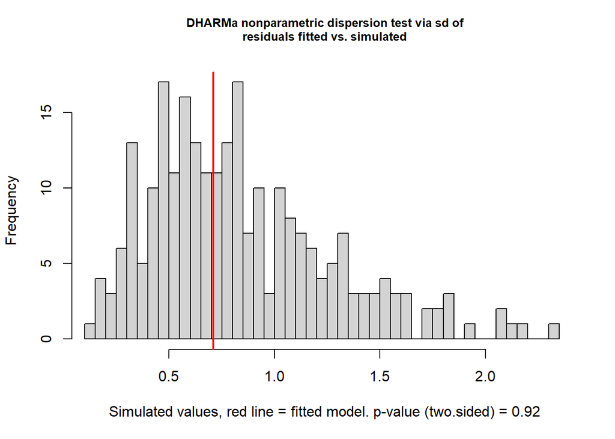

```
##
##  DHARMa nonparametric dispersion test via sd of residuals fitted vs.
##  simulated
##
## data:  simulationOutput
## dispersion = 0.84221, p-value = 0.92
## alternative hypothesis: two.sided
```

```r
testDispersion(hct_amb_fec_no_atresia_lm_sqrt)
```

```r
# Residuals of model for shapiro test
hct_amb_fec_no_atresia_lm_res <- residuals(hct_amb_fec_no_atresia_lm_sqrt)

# Normality test
shapiro.test(hct_amb_fec_no_atresia_lm_res)
```

```
##
##  Shapiro-Wilk normality test
##
## data:  hct_amb_fec_no_atresia_lm_res
## W = 0.87306, p-value = 0.1615
```

```r
# Parametric variance test: bartlett's test
# Require at least 2 obs for each group
#bartlett.test(Hct.... ~ Weight_Adjusted_Fecundity_Fecundity.Mean_Weight, data = hct_ambient_sqrt)

# Nonparametric variance test (Levene's test)
# NA for quantitative explanatory variables
# leveneTest(Hct.... ~ Weight_Adjusted_Fecundity_Fecundity.Mean_Weight, data = hct_ambient_sqrt)
```

Hct Ambient No Atresia Results

## Does a significant correlation exist between weight adj fecundity and parameter?

Parametric assumptions: - Normality (Shapiro-Wilk test): **Met** - Variance (Bartlett’s test): NA

Nonparametric variance test (Levene’s test): NA

Residuals Plot (if significant)

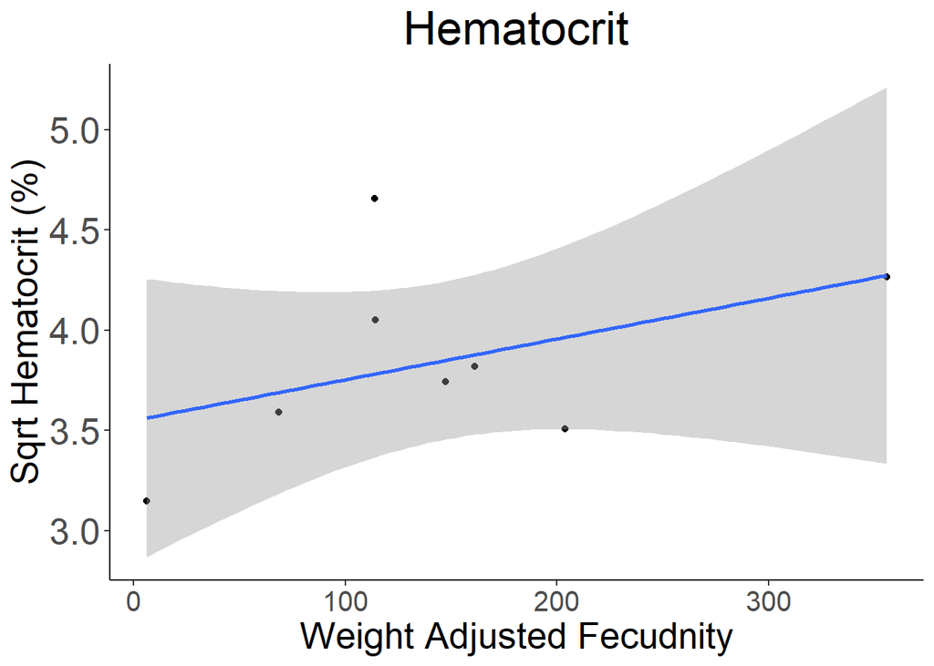

```r
# hct
# Ambient samples

# ggplot with geom_smooth(aes(x=,y=)), method = "lm")

hct_ambient_lm_scatterplot <- ggplot(data = hct_ambient_sqrt, aes(x = Weight_Adjusted_Fecundity_Fecundity.Mean_Weight, y = Hct....)) +
  geom_point() +
  geom_smooth(aes(group = 1), method = "lm") +
  labs(title = "Hematocrit", x = "Weight Adjusted Fecudnity", y = "Sqrt Hematocrit (%)", color = "Category") +
  scale_y_continuous() +
  theme_classic() +
  theme(panel.background = element_rect(fill = "white"),
        plot.background = element_rect(fill = "white"),
        legend.background = element_rect(fill = "white", color = "black"),
        plot.title = element_text(size = 25, hjust = 0.5),
        axis.text.x = element_text(size = 15),
        axis.text.y = element_text(size = 20),
        axis.title.x = element_text(size = 20),
        axis.title.y = element_text(size = 20))

print(hct_ambient_lm_scatterplot)
```

```r
ggsave(filename = "data-images/hct_ambient_lm_scatterplot.pdf", plot = hct_ambient_lm_scatterplot, device = "pdf")
ggsave(filename = "data-images/hct_ambient_lm_scatterplot.png", plot = hct_ambient_lm_scatterplot, device = "png")
```

# Glucose

glucose Summary Stats

```r
# glucose
# Summary stats

# Ambient data
Ambient_Samples %>%
  group_by(Ambient.Or.OAH, Consensus_Brood_Condition) %>%
  summarize(count = n(),
            median = round(median(Glu..mmol.L.), 3),
            mean = round(mean(Glu..mmol.L.), 3),
            sd = round(sd(Glu..mmol.L.), 3),
            cv = round(sd(Glu..mmol.L.)/mean(Glu..mmol.L.), 3)) %>%
  ungroup()
```

```
## # A tibble: 4 × 7
##   Ambient.Or.OAH Consensus_Brood_Condition count median  mean     sd     cv
##   <ord>          <ord>                     <int>  <dbl> <dbl>  <dbl>  <dbl>
## 1 Ambient        Excellent                     1   1.8   1.8  NA     NA
## 2 Ambient        Normal                        4   1.55  1.58  0.275  0.175
## 3 Ambient        Low                           3   1.1   1.6   1.04   0.653
## 4 Ambient        Atresia                      13   2     2.1   0.698  0.332
```

```r
Ambient_Samples %>%
  group_by(Ambient.Or.OAH, Fecundity_Class) %>%
  summarize(count = n(),
            median = round(median(Glu..mmol.L.), 3),
            mean = round(mean(Glu..mmol.L.), 3),
            sd = round(sd(Glu..mmol.L.), 3),
            cv = round(sd(Glu..mmol.L.)/mean(Glu..mmol.L.), 3)) %>%
  ungroup()
```

```
## # A tibble: 3 × 7
##   Ambient.Or.OAH Fecundity_Class count median  mean    sd    cv
##   <ord>          <ord>           <int>  <dbl> <dbl> <dbl> <dbl>
## 1 Ambient        High (>50,000)      4   1.55  1.55 0.238 0.154
## 2 Ambient        Low (~1,000s)       4   1.5   1.68 0.866 0.517
## 3 Ambient        Atresia            13   2     2.1  0.698 0.332
```

```r
Amb_Fec_No_Atresia_Samples %>%
  group_by(Ambient.Or.OAH, Fecundity_Class) %>%
  summarize(count = n(),
            median = round(median(Glu..mmol.L.), 3),
            mean = round(mean(Glu..mmol.L.), 3),
            sd = round(sd(Glu..mmol.L.), 3),
            cv = round(sd(Glu..mmol.L.)/mean(Glu..mmol.L.), 3)) %>%
  ungroup()
```

```
## # A tibble: 2 × 7
##   Ambient.Or.OAH Fecundity_Class count median  mean    sd    cv
##   <ord>          <ord>           <int>  <dbl> <dbl> <dbl> <dbl>
## 1 Ambient        High (>50,000)      4   1.55  1.55 0.238 0.154
## 2 Ambient        Low (~1,000s)       4   1.5   1.68 0.866 0.517
```

Glucose Boxplot

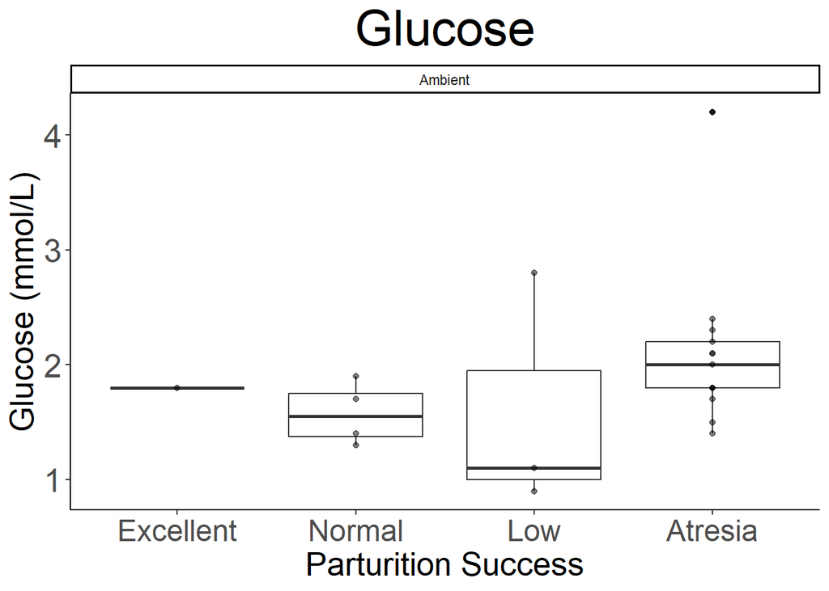

```r
# glucose boxplot

# Ambient Samples
glucose_ambient_boxplot <- ggplot(data = Ambient_Samples) +
  geom_boxplot(aes(x = Consensus_Brood_Condition, y = Glu..mmol.L.)) +
  geom_point(aes(x = Consensus_Brood_Condition, y = Glu..mmol.L.), alpha = 0.5, colour = "black") +
  labs(title = "Glucose", x = "Parturition Success", y = "Glucose (mmol/L)") +
  facet_wrap(~ Ambient.Or.OAH) +
  theme_classic() +
  theme(panel.background = element_rect(fill = "white"),
        plot.background = element_rect(fill = "white"),
        legend.background = element_rect(fill = "white", color = "black"),
        title = element_text(size = 12),
        plot.title = element_text(size = 30, hjust = 0.5),
        axis.text.x = element_text(size = 18),
        axis.text.y = element_text(size = 20),
        axis.title.x = element_text(size = 20),
        axis.title.y = element_text(size = 20))

print(glucose_ambient_boxplot)
```

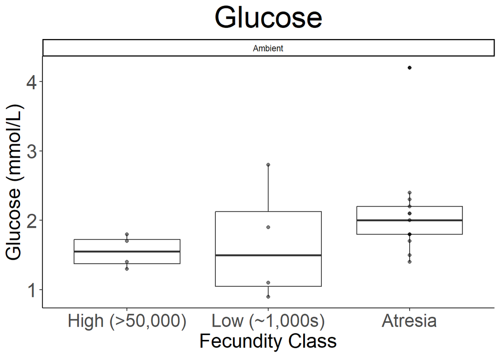

```r
ggsave(filename = "data-images/glucose_ambient_boxplot.pdf", plot = glucose_ambient_boxplot, device = "pdf")
ggsave(filename = "data-images/glucose_ambient_boxplot.png", plot = glucose_ambient_boxplot, device = "png")
glucose_ambient_fecundity_boxplot <- ggplot(data = Ambient_Samples) +
  geom_boxplot(aes(x = Fecundity_Class, y = Glu..mmol.L.)) +
  geom_point(aes(x = Fecundity_Class, y = Glu..mmol.L.), alpha = 0.5, colour = "black") +
  labs(title = "Glucose", x = "Fecundity Class", y = "Glucose (mmol/L)") +
  facet_wrap(~ Ambient.Or.OAH) +
  theme_classic() +
  theme(panel.background = element_rect(fill = "white"),
        plot.background = element_rect(fill = "white"),
        legend.background = element_rect(fill = "white", color = "black"),
        title = element_text(size = 12),
        plot.title = element_text(size = 30, hjust = 0.5),
        axis.text.x = element_text(size = 18),
        axis.text.y = element_text(size = 20),
        axis.title.x = element_text(size = 20),
        axis.title.y = element_text(size = 20))

print(glucose_ambient_fecundity_boxplot)
```